# nktcan

Daniel Spakowicz

5/19/2020

The following are a series of power calculations to support the study of NKTcells in cancer, citing a question of interest and then an analysis and associated sample size and power to address it.

# Do lymph nodes involved in tumors have more NKTcells than uninvolved lymph nodes?

Important numbers for this calculation:

- A lymph sampled by endobronchial ultrasound (EBUS) can sample 1e5 - 1e6 lymphocytes
- Of those an estimated 0.2% are NKTcells
- This is an intra-individual question, and therefore is expected to have relatively low coefficient of variation CV = 0.3-0.5

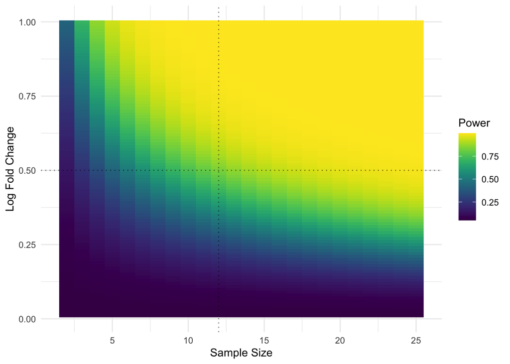

```r
# NKTcells collected per sample
ebus.lymph <- 1e6
lymph.nkt.frac <- 0.002
nkt.col <- ebus.lymph * lymph.nkt.frac

# Difference in the fraction of NKTcells, negative binomial distribution
n <- seq(2, 25)
log.fc <- seq(0.01, 1, by = 0.01)

# Calculate power
power.l <- list()
for (i in 1:length(n)) {
  power.l[[as.character(n[i])]] <-
    power.hart(n = i,
               alpha = 0.05,
               log.fc = log.fc,
               mu = rep(nkt.col, length(log.fc)),
               sig = rep(0.4, length(log.fc)))
}

# Convert to long-format data frame
power.df <-
  power.l %>%
  bind_rows() %>%
  mutate(log.fc = log.fc) %>%
  gather(n, power, -log.fc) %>%
  mutate(n = as.numeric(n)) %>%
  mutate(fold.change = 2^log.fc)

a1.rep <-
  power.df %>%
  filter(power >= 0.8) %>%
  filter(log.fc == 0.5) %>%
  head(., 1)

# Plot result
power.df %>%
  ggplot(aes(x = n, y = log.fc, z = power)) +
  geom_raster(aes(fill = power)) +
  labs(x = "Sample Size",
       y = "Log Fold Change",
       fill = "Power") +
  theme_minimal() +
  scale_fill_viridis() +
  geom_hline(aes(yintercept = 0.5), linetype = "dotted", alpha = 0.5) +
  geom_vline(xintercept = a1.rep$n, linetype = "dotted", alpha = 0.5)
```

```r
  ggsave("figures/nkt-diff_lymphnodes.png", height = 3, width = 4)
```

> The NKTcells will be calculated as a fraction of total lymphocytes. As such, power is estimated as a negative binomial distribution Wald test using the FDRsamplesize package in R. A sample size of 12 is sufficient to detect a 1.4142136 fold change in NKTcell populations with 0.8332225 ($\alpha$ = 0.05, coefficient of variation = 0.4). Code to reproduce all simulations and calculations is available at https://github.com/spakowiczlab/nktcan.

# Do cancer patients have increased numbers of circulating NKTcells?

There are three cohorts that could be used to address this question at OSU 1) Cancer patients (collected under OSU-?) 2) No cancer, but at high risk (BE WELL Study participants (NCT04267874)) 3) Healthy volunteers (collected under OSU-?)

- 30-90 million PBMCs from 12 mL blood
- 80-90% of PBMCs are lymphocytes
- 1-2% of lymphocytes are NKTcells

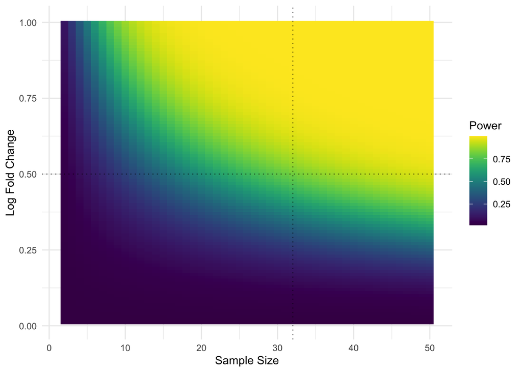

```r
# NKTcells collected per 12 mL blood sample
pbmc.cells <- 90e6
lymphocyte.pmbc.frac <- 0.9
nkt.of.lymphocytes <- 0.02
nkt.in.sample <- pbmc.cells * lymphocyte.pmbc.frac * nkt.of.lymphocytes

# Difference in the fraction of NKTcells, negative binomial distribution
n <- seq(2, 50)
log.fc <- seq(0.01, 1, by = 0.01)

# Number of tests (all pairwise comparisons, three groups)
n.tests <- 3

# Calculate power
power.l <- list()
for (i in 1:length(n)) {
  power.l[[as.character(n[i])]] <-
    power.hart(n = i,
               alpha = 0.05/n.tests,
               log.fc = log.fc,
               mu = rep(nkt.in.sample, length(log.fc)),
               sig = rep(0.6, length(log.fc)))
}

# Convert to long-format data frame
power.df <-
  power.l %>%
  bind_rows() %>%
  mutate(log.fc = log.fc) %>%
  gather(n, power, -log.fc) %>%
  mutate(n = as.numeric(n)) %>%
  mutate(fold.change = 2^log.fc)

a2.rep <-
  power.df %>%
  filter(power >= 0.8) %>%
  filter(log.fc == 0.5) %>%
  head(., 1)

# Plot result
power.df %>%
  ggplot(aes(x = n, y = log.fc, z = power)) +
  geom_raster(aes(fill = power)) +
  labs(x = "Sample Size",
       y = "Log Fold Change",
       fill = "Power") +
  theme_minimal() +
  scale_fill_viridis() +
  geom_hline(aes(yintercept = 0.5), linetype = "dotted", alpha = 0.5) +
  geom_vline(xintercept = a2.rep$n, linetype = "dotted", alpha = 0.5)
```

```r
  ggsave("figures/nkt-diff_pbmcs.png", height = 3, width = 4)
```

> In the context of detecting differences between three groups (cancer, high-risk and healthy), a sample size of 32 is sufficient to detect a 1.4142136 fold change in NKTcell populations with 0.8124213 ($\alpha$ = 0.05, coefficient of variation = 0.6).

## What is the smallest subpopulation of NKTcells that could be analyzed with this blood sample size?

- NKTcells come in several subtypes, roughly <= 5 (e.g type I and type II) are expected

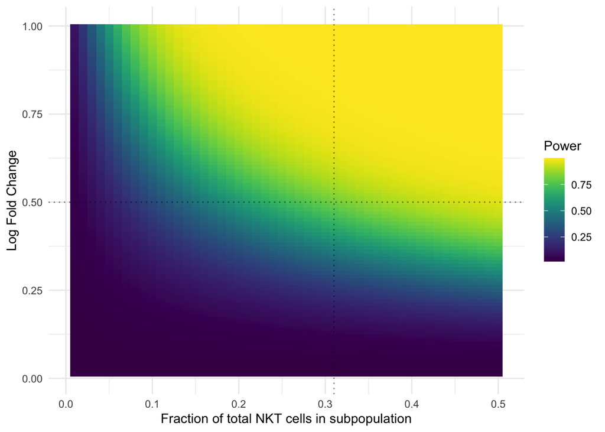

```r
# NKTcells collected per 12 mL blood sample
nkt.subpop.frac <- seq(.01, .50, by = 0.01) # percent of total
nkt.subpop.n <- nkt.in.sample * nkt.subpop.frac

# Difference in the fraction of NKTcells, negative binomial distribution
n <- a2.rep$n

# Number of tests (all pairwise comparisons, three groups)
n.tests <- 3

# Calculate power
power.l <- list()
for (i in 1:length(nkt.subpop.n)) {
  power.l[[as.character(nkt.subpop.n[i])]] <-
    power.hart(n = i,
               alpha = 0.05/n.tests,
               log.fc = log.fc,
               mu = rep(nkt.subpop.n[i], length(log.fc)),
               sig = rep(0.6, length(log.fc)))
}

# Convert to long-format data frame
power.df <-
  power.l %>%
  bind_rows() %>%
  mutate(log.fc = log.fc) %>%
  gather(n, power, -log.fc) %>%
  mutate(n.nkt.subpop = as.numeric(n)) %>%
  mutate(nkt.subpop.fraction = n.nkt.subpop / nkt.in.sample) %>%
  mutate(fold.change = 2^log.fc)

a2.1.rep <-
  power.df %>%
  filter(power >= 0.8) %>%
  filter(log.fc == 0.5) %>%
  head(., 1)

# Plot result
power.df %>%
  ggplot(aes(x = nkt.subpop.fraction, y = log.fc, z = power)) +
  geom_raster(aes(fill = power)) +
  labs(x = "Fraction of total NKT cells in subpopulation",
       y = "Log Fold Change",
       fill = "Power") +
  theme_minimal() +
  scale_fill_viridis() +
  geom_hline(aes(yintercept = 0.5), linetype = "dotted", alpha = 0.5) +
  geom_vline(xintercept = a2.1.rep$nkt.subpop.fraction, linetype = "dotted", alpha = 0.5) +
  ggsave("figures/nkt-subpop_pbmcs.png", height = 3, width = 4)
```

A subpopulation that is 31% of the total isolated NKTcells could be detected as different from the other groups with 0.8124196 power.